# Flight Analysis

# MSA Summer Practicum

The task was to take the flight dataset and make some value for US DOT executive. The assignment was open-ended and non-directed. At the culmination of the summer session, each team delivered a 20 minute presentation outlining their analyses.

I, Max Spehlmann, worked with a team of 4 Master’s students, Zane Potorti, Salem Wear, Teresa Meng, and Rena Marrotta. We decided to create a logistic model that predicts the carrier delay of a flight. If a flight is considered delayed due to factors within the airline’s control, it is referred to as a carrier delay.

# Importing the Datasets

First things first, let’s get our R environment set up with the proper packages.

```r
knitr::opts_chunk$set(message = FALSE)
library(tidyverse)
library(here)
library(lubridate)
library(car)
library(here)
library(dplyr)
library(glmnet)
library(survival)
library(gmodels)
library(Metrics)
library(ggplot2)
#library(Dict)
```

These datasets were downloaded from the US DOT Transtats repository. Accessible here, https://www.transtats.bts.gov/tables.asp?qo_vq=EFD&QO_anzr=

We begin by defining a function to sort out parsing errors.

```r
import_remove_parsing_errors <- function(input_file_path){

#import, let readr try to guess all the column types with default settings
current_import <- read_csv(input_file_path, col_types = cols(FlightDate = col_date(format = "%Y-%m-%d")))


#many issues were detected. Find the last row with a parsing issue
last_row_with_issue <- max(problems(current_import)$row)

#reimport to remove errors
current_import <- read_csv(input_file_path, col_types = cols(FlightDate = col_date(format = "%Y-%m-%d")),guess_max = last_row_with_issue)

#figure out which columns are only filled with NA
remove_vars <- colnames(current_import[which(!is.na(current_import[,dim(current_import)[[2]]])), dim(current_import)[[2]]])

#filter them out
current_import <- current_import %>% select(-all_of(remove_vars))

#return the clean data
return(current_import)
}
```

Then we make a function to save all of the .csv files as .Rdata files, so that the data types will be correctly set anytime we re-import the data to our R environment.

```r
compare_two_imports <- function(df_ref, df_new){
  column_info_ref <- data.frame(
  Column_Name = names(df_ref),
  Column_Type = sapply(df_ref, class),
  stringsAsFactors = FALSE)

  column_info_new <- data.frame(
  Column_Name = names(df_new),
  Column_Type = sapply(df_new, class),
  stringsAsFactors = FALSE)

 dif_values <- column_info_ref %>%
  mutate(same_values = Column_Name == column_info_new$Column_Name &
           Column_Type == column_info_new$Column_Type) %>%
  filter(!same_values)

return(dif_values)
}

save_it_up <- function(input_df){
  calling_variable_plus_RData <- paste(deparse(substitute(input_df)),".RData", sep = "")
  save(input_df, file = here("r_data", calling_variable_plus_RData))
}
```

This is the code to import the csv’s from the transtats database. If you would like to update these values, you may. Currently the script pulls in data from April 2022 - March 2023.

```r
twenty_three_one <- import_remove_parsing_errors('On_Time_Marketing_Carrier_On_Time_Performance_(Beginning_January_2018)_2023_1.csv')

save_it_up(twenty_three_one)

twenty_three_two <- import_remove_parsing_errors('On_Time_Marketing_Carrier_On_Time_Performance_(Beginning_January_2018)_2023_2.csv')

compare_two_imports(twenty_three_one, twenty_three_two)

save_it_up(twenty_three_two)

twenty_three_three <- import_remove_parsing_errors('On_Time_Marketing_Carrier_On_Time_Performance_(Beginning_January_2018)_2023_3.csv')

compare_two_imports(twenty_three_one, twenty_three_three)

save_it_up(twenty_three_three)

twenty_two_four <- import_remove_parsing_errors('On_Time_Marketing_Carrier_On_Time_Performance_(Beginning_January_2018)_2022_4.csv')

compare_two_imports(twenty_three_one, twenty_two_four)

save_it_up(twenty_two_four)

twenty_two_five <- import_remove_parsing_errors('On_Time_Marketing_Carrier_On_Time_Performance_(Beginning_January_2018)_2022_5.csv')

compare_two_imports(twenty_two_four, twenty_two_five)

save_it_up(twenty_two_five)

twenty_two_six <- import_remove_parsing_errors('On_Time_Marketing_Carrier_On_Time_Performance_(Beginning_January_2018)_2022_6.csv')

compare_two_imports(twenty_two_four, twenty_two_six)

save_it_up(twenty_two_six)

twenty_two_seven <- import_remove_parsing_errors('On_Time_Marketing_Carrier_On_Time_Performance_(Beginning_January_2018)_2022_7.csv')

compare_two_imports(twenty_two_four, twenty_two_seven)

save_it_up(twenty_two_seven)

twenty_two_eight <- import_remove_parsing_errors('On_Time_Marketing_Carrier_On_Time_Performance_(Beginning_January_2018)_2022_8.csv')

compare_two_imports(twenty_two_four, twenty_two_eight)

save_it_up(twenty_two_eight)

twenty_two_nine <- import_remove_parsing_errors('On_Time_Marketing_Carrier_On_Time_Performance_(Beginning_January_2018)_2022_9.csv')

compare_two_imports(twenty_two_four, twenty_two_nine)

save_it_up(twenty_two_nine)

twenty_two_ten <- import_remove_parsing_errors('On_Time_Marketing_Carrier_On_Time_Performance_(Beginning_January_2018)_2022_10.csv')

compare_two_imports(twenty_two_four, twenty_two_ten)

save_it_up(twenty_two_ten)

twenty_two_eleven <- import_remove_parsing_errors('On_Time_Marketing_Carrier_On_Time_Performance_(Beginning_January_2018)_2022_11.csv')

compare_two_imports(twenty_two_four, twenty_two_eleven)

save_it_up(twenty_two_eleven)

twenty_two_twelve <- import_remove_parsing_errors('On_Time_Marketing_Carrier_On_Time_Performance_(Beginning_January_2018)_2022_12.csv')

compare_two_imports(twenty_two_four, twenty_two_twelve)

save_it_up(twenty_two_twelve)
```

# Combining and Subsetting the Datasets

Now we are going to combine all of the flight data from all of the months into one dataframe. We can use the bind_rows() function from the tidyverse package because we ensured all of the columns were parsed correctly.

This function will load all of the .Rdata files that we saved when we imported the .csv’s above.

```r
df_names <- c("twenty_three_one", "twenty_three_two", "twenty_three_three", "twenty_two_four", "twenty_two_five", "twenty_two_six", "twenty_two_seven", "twenty_two_eight", "twenty_two_nine", "twenty_two_ten", "twenty_two_eleven", "twenty_two_twelve")

smartLoad <- function(input_names){
  df_list <- list()
  for(i in seq_along(input_names)){
    file_name <- paste0(input_names[[i]], ".RData")
    load(here("r_data", file_name))
    df_list[[input_names[[i]]]] <- input_df
  }
  return(df_list)
}

all_data_list <- smartLoad(df_names)

all_data_list[[7]]["Div2WheelsOff"] <- as.character(all_data_list[[7]][["Div2WheelsOff"]])

all_data_df <- bind_rows(all_data_list)
```

Here we subsetted our data by the 10 most busy airports. We then selected only flights that flew between two airports that were each top 10 airports. We also subsetted by the ten most busy airlines. Feel free to change these values to generate unique subsets, or use the entire datasets on your local machine.

```r
full <- all_data_df

top_airports <- c("ATL",  "DFW",  "DEN", "ORD",  "LAX", "CLT", "MCO", "LAS","PHX", "MIA")
full <- full %>%
  filter(Origin %in% top_airports) %>%
  filter(Dest %in% top_airports)

full <- full %>%
  mutate(Route = paste(Origin, Dest, sep=""))%>%
  mutate(Route = as.factor(Route))

full <- full %>%
  mutate(Carrier_Category = case_when(
    Operating_Airline == "WN" ~ 0,
    Operating_Airline == "NK" ~ 0,
    Operating_Airline == "B6" ~ 0,
    Operating_Airline == "F9" ~ 0,
    Operating_Airline == "G4" ~ 0,
    Operating_Airline == "AA" ~ 1,
    Operating_Airline == "DL" ~ 1,
    Operating_Airline == "UA" ~ 1,
    Operating_Airline == "HA" ~ 1,
    Operating_Airline == "AS" ~ 1,
    TRUE ~ 2
  )) %>%
  mutate(Carrier_Category = as.factor(Carrier_Category))

full <- full %>% filter(!(Carrier_Category == 2))

full <- full %>%
  group_by(Operating_Airline, FlightDate) %>%
  mutate(FlightsPerAirline = n()) %>%
  ungroup()

full <- full %>%
  group_by(Origin, FlightDate) %>%
  mutate(FlightsPerOrgAirport = n()) %>%
  ungroup()

#Removes irrelevant variables and factors necessary ones
full <- full %>% mutate(Quarter = as.factor(Quarter), Month = as.factor(Month), DayofMonth = as.factor(DayofMonth), DayOfWeek = as.factor(DayOfWeek), Carrier_Category = as.factor(Carrier_Category)) %>% select(CarrierDelay, FlightDate, FlightsPerAirline, FlightsPerOrgAirport, Marketing_Airline_Network, Operating_Airline, Origin, Dest, Distance, Tail_Number, Route, Quarter, Month, DayofMonth, DayOfWeek, Carrier_Category, DepTime, ArrTime, LateAircraftDelay)

save(full, file = here("r_data", "all_data_subsetted.RData"))

write.csv(full, here("raw_data","subsetted_data.csv"), row.names = F)
```

# Transforming and Joining the Data

We decided to use the FAA Civil Aviation Registry to pull in data relating the tail number of all the planes to information about the aircraft, e.g., the model of the plane, the number of seats, the date of construction, etc.

We began by creating a profile of all of the aircraft in our subsetted data.

```r
master <- read.csv(here("raw_data", "MASTER.csv"), colClasses=c("ENG.MFR.MDL"='character'))
colnames(master)[1]='Tail_Number'

master$Tail_Number <- paste("N",master$Tail_Number, sep='')
engineInfo <- read.csv(here("raw_data","ENGINE.csv"),colClasses=c("ï..CODE"='character'))
colnames(engineInfo)[1:4]=c('ENG.MFR.MDL', 'MFR.ENG','MODEL.ENG','TYPE.ENG')
aircraftRef <- read.csv(here("raw_data","ACFTREF.csv"))
colnames(aircraftRef)[1:4]=c('MFR.MDL.CODE','MFR.ACFT','MODEL.ACFT','TYPE.ACFT')

#establishes a profile for each unique plane
planeDB <- data.frame(Tail_Number=c(unique(full$Tail_Number)), numFlights = 0, airTime = 0)

#Initializes progress report variables
computingProgress = 0
computingStep = round(nrow(full)/100,0)

#populating profile fields
for (fullIndex in seq(1,nrow(full))){
    #matches the plane in "full" with its profile
  planeIndex = which(planeDB$Tail_Number==full$Tail_Number[fullIndex])

    #counts the number of flights each plane goes on
  planeDB$numFlights[planeIndex] = planeDB$numFlights[planeIndex]+1

  #Intermittent progress report
  if(!(fullIndex%%computingStep)){
    computingProgress = computingProgress + 1
    print(paste('Completion:',computingProgress,'%'))
  }
}

#creates the full master list with plane and engine info by tail number
PlaneProfiles <- master %>%
  left_join(aircraftRef, by='MFR.MDL.CODE') %>%
  left_join(engineInfo, by='ENG.MFR.MDL') %>%
  left_join(planeDB[,c('Tail_Number','numFlights')],by='Tail_Number')
save(PlaneProfiles,file=here("r_data",'PlaneProfiles.RData'))

#creates the holiday variable for all days in the year
holidayDF <- data.frame(DayofMonth = c(rep(seq(1,31),12)), Month =c( c(rep(1,31)),c(rep(2,31)),c(rep(3,31)),c(rep(4,31)),c(rep(5,31)),c(rep(6,31)),c(rep(7,31)),c(rep(8,31)),c(rep(9,31)),c(rep(10,31)),c(rep(11,31)),c(rep(12,31))),holiday=0)
#assigns holidays to labor day, memorial day, july 4, thanksgiving, and christmas-new years, as well as the day before/after
holidayDF[c(5*31,5*31-1,5*31-2),3]=1
holidayDF[c(12*31,12*31-1,12*31-2,12*31-3,12*31-4,12*31-5,12*31-6,12*31-7,12*31-8),3]=1
holidayDF[c(8*31+5,8*31+6,8*31+4),3]=1
holidayDF[c(11*31-8,11*31-7,11*31-6),3]=1
holidayDF[c(6*31+3,6*31+4,6*31+5),3]=1
save(holidayDF,file='holidayDF.RData')
```

Because delays tend to compound (if a plane is delayed for one flight, it is more likely to be delayed on subsequent flights) we corrected the non-independence of flight delays.

```r
#Initialize dataframe
prevDelayInfo <- full %>% select(DepTime, ArrTime, CarrierDelay, FlightDate, Tail_Number)

#Formats DepTime and ArrTime in a usable way
prevDelayInfo <- prevDelayInfo %>% mutate(DepTime = strptime(DepTime, format = "%H%M"), ArrTime = strptime(ArrTime, format = "%H%M")) %>% mutate(DepTime = format(DepTime,format="%H:%M"), ArrTime = format(ArrTime,format="%H:%M")) %>%
  mutate(prevCarrierDelay = 0, timeSinceLastFlight = 0) %>% #creates a variable for the delay of a plane's last flight
  group_by(Tail_Number) %>% arrange(FlightDate, DepTime, .by_group=TRUE) #arranges the flights so all of a given plane's flights are adjacent and in order

#Replaces NAs with 99:99 to avoid errors later on
prevDelayInfo$DepTime <- replace_na(prevDelayInfo$DepTime, '99:99')
prevDelayInfo$ArrTime <- replace_na(prevDelayInfo$ArrTime, '99:99')

#Iterates over all flights. This excludes the last flight because that one has no following flight to compare with
for (rowIndex in seq(1,nrow(prevDelayInfo)-1)){
  nextIndex=rowIndex+1 #code breaks without indexing this specific way

  #If the two flights used the same valid plane, this records whether there was a carrier delay for the first flight within the second flight's row. I'm not sure why but some of these conditional statements below only return usable values when when index [[1]] is called
  if((!is.na(prevDelayInfo$Tail_Number[rowIndex]) & !is.na(prevDelayInfo$Tail_Number[nextIndex]))[[1]] & (prevDelayInfo$Tail_Number[rowIndex]==prevDelayInfo$Tail_Number[nextIndex])[[1]]){
      prevDelayInfo$prevCarrierDelay[rowIndex+1]=prevDelayInfo$CarrierDelay[rowIndex]
    }

  #Checks if the 2 flights have the same valid tail numbers and valid departure times
  if((!is.na(prevDelayInfo$Tail_Number[rowIndex]) & !is.na(prevDelayInfo$Tail_Number[nextIndex]))[[1]] & (prevDelayInfo$Tail_Number[rowIndex]==prevDelayInfo$Tail_Number[nextIndex])[[1]] &
prevDelayInfo$DepTime[rowIndex] != "99:99" &
prevDelayInfo$DepTime[nextIndex] != "99:99"){

    #If the 2 flights are on the same day, records the time between the flights
      if((day(prevDelayInfo$FlightDate[rowIndex])==day(prevDelayInfo$FlightDate[nextIndex])[[1]])){
        prevDelayInfo$timeSinceLastFlight[nextIndex] <- as.numeric((hm(prevDelayInfo$DepTime[nextIndex])-hm(prevDelayInfo$ArrTime[rowIndex])))
    #If the 2 flights are on adjacent days, records the time between the flights
      } else if((day(prevDelayInfo$FlightDate[rowIndex]+1)==day(prevDelayInfo$FlightDate[nextIndex])[[1]])){
        prevDelayInfo$timeSinceLastFlight[nextIndex] <- as.numeric((hm(prevDelayInfo$DepTime[nextIndex])+hm("24:00")-hm(prevDelayInfo$ArrTime[rowIndex])))
      }
    }
}

#Reformats DepTime to be used as a join key with full, removes obsolete variables
prevDelayInfo <- prevDelayInfo %>% select(-c(ArrTime, CarrierDelay)) %>% rowwise() %>% mutate(DepTime = paste(paste(strsplit(prevDelayInfo$DepTime, split='')[[1]][1:2],collapse=''),':',paste(strsplit(prevDelayInfo$DepTime, split='')[[1]][3:4],collapse=''),collapse=''))

save(prevDelayInfo, file=here("r_data","prevDelayInfo.RData"))
```

Next, we added variables related to holidays, joined our plane profiles to the flight datasets, and corrected missing values.

```r
load(here("r_data","all_data_subsetted.RData"))

load(here("r_data",'PlaneProfiles.RData'))

load(here("r_data",'holidayDF.RData'))

load(here("r_data",'CarrierDelayTimeSinceLastFlight.RData'))

holidayDF <- holidayDF %>% mutate(DayofMonth = as.factor(DayofMonth)) %>% mutate(Month = as.factor(Month))

full <- full %>% left_join(PlaneProfiles, by='Tail_Number') %>% left_join(holidayDF,by=c('DayofMonth','Month')) %>% left_join(CarrierDelayTimeSinceLastFlight, by=c('Tail_Number','FlightDate','DepTime'))


#Fixing duplicated variable
full$TYPE.ENG <- full$TYPE.ENG.x

#fixing weird variable
full <- full %>% mutate(YEAR.MFR = ifelse(YEAR.MFR==2011.152, 2011.000, YEAR.MFR))
unique(full$YEAR.MFR)

#Treatment for NAs
full$DepDelay <- replace_na(full$DepDelay,0)
full$CarrierDelay <- replace_na(full$CarrierDelay,0)
full$LateAircraftDelay <- replace_na(full$LateAircraftDelay,0)
full$WeatherDelay <- replace_na(full$WeatherDelay,0)
full$TYPE.ENG <- replace_na(full$TYPE.ENG,0)
full$THRUST <- replace_na(full$THRUST,0) #horsepower and thrust are set to 0 because the creator of the master file set unknown values to 0 already and there's few enough values to factor them
full$HORSEPOWER <- replace_na(full$HORSEPOWER,0)
full$prevCarrierDelay <- replace_na(full$prevCarrierDelay, 0)
full$minutesSinceLastFlight <- replace_na(full$minutesSinceLastFlight, 1440)
full$MODEL.ENG <- replace_na(full$MODEL.ENG,'UNKNOWN')
full$MFR.ENG <- replace_na(full$MFR.ENG,'UNKNOWN')
full$MODEL.ACFT <- replace_na(full$MODEL.ACFT,'UNKNOWN')
full$Tail_Number <- replace_na(full$Tail_Number, 'UNKNOWN')
full$NO.SEATS[is.na(full$NO.SEATS)]<-mean(full$NO.SEATS,na.rm=TRUE)
full$YEAR.MFR[is.na(full$YEAR.MFR)]<-mean(full$YEAR.MFR,na.rm=TRUE)
full$numFlights[is.na(full$numFlights)]<-mean(full$numFlights,na.rm=TRUE)
full$DepTime <- replace_na(full$DepTime, '99:99')
full$ArrTime <- replace_na(full$ArrTime, '99:99')

#Removes irrelevant variables and factors necessary ones
full <- full %>% mutate(Quarter = as.factor(Quarter), Month = as.factor(Month), DayofMonth = as.factor(DayofMonth), DayOfWeek = as.factor(DayOfWeek), Carrier_Category = as.factor(Carrier_Category), MODEL.ENG =  as.factor(MODEL.ENG), HORSEPOWER = as.factor(HORSEPOWER), THRUST = as.factor(THRUST), TYPE.ENG = as.factor(TYPE.ENG)) %>% select(CarrierDelay, FlightDate, FlightsPerAirline, FlightsPerOrgAirport, Marketing_Airline_Network, Operating_Airline, Origin, Dest, Distance, Tail_Number, Route, numFlights, holiday, YEAR.MFR, MODEL.ACFT, NO.SEATS, MFR.ENG, Quarter, Month, DayofMonth, DayOfWeek, Carrier_Category, MODEL.ENG, HORSEPOWER, THRUST, TYPE.ENG, DepTime, ArrTime, minutesSinceLastFlight, prevCarrierDelay, LateAircraftDelay)

#Adding transformations

full$logCarrierDelay <- log(full$CarrierDelay)
full$logPrevCarrierDelay <- log(full$prevCarrierDelay)
full$recipRootCarrierDelay <- -1/sqrt(full$CarrierDelay)
full$recipRootCarrierDelay <- replace_na(full$recipRootCarrierDelay, -1)
full$probCarrierDelay <- ifelse(full$CarrierDelay>0, 1, 0)

save(full, file = here("r_data", "all_data_subsetted_with_joins_and_transformations_NAs_processed.RData"))
```

# Splitting the Data

Next we were ready to split the flight dataset into train and test subsets so that we could create a model predicting flight delays.

```r
#this will import "full" df

load(file = here("r_data","all_data_subsetted_with_joins_and_transformations_NAs_processed.RData"))

#we will use a split of 0.7 for training and 0.3 for testing

set.seed(123)

# Generate random indices for splitting
indices <- sample(1:nrow(full))

# Calculate the number of rows for each subset
num_rows <- nrow(full)
train_rows <- round(0.7 * num_rows)
test_rows <- num_rows - train_rows

# Split the dataframe into subsets
train_data <- full[indices[1:train_rows], ]
test_data <- full[indices[(train_rows + 1):num_rows], ]

#Changes the only G4 flight with a carrier delay to the training data. Otherwise models cannot function. Run this by hand.
train_data[which(train_data$Operating_Airline=='G4'),]
test_data[which(test_data$Operating_Airline=='G4'),]
which(test_data$Operating_Airline=='G4')
train_data <- rbind(train_data, test_data[43268,])
test_data <- test_data[-c(43268),]
test_data[43268]

#save these objects
save(train_data, file=here("r_data","train_data.RData"))
save(test_data, file=here("r_data","test_data.Rdata"))
```

# Modeling

```r
load(file = here("r_data","all_data_subsetted_with_joins_and_transformations_NAs_processed.RData"))
load(file = here("r_data","test_data.RData"))
load(file = here("r_data","train_data.RData"))

train_data$Operating_Airline <- factor(train_data$Operating_Airline, levels=c("G4", "AS","B6","DL","NK","UA","WN","AA","F9", "HA"))
test_data$Operating_Airline <- factor(test_data$Operating_Airline, levels=c("G4", "AS","B6","DL","NK","UA","WN","AA","F9", "HA"))

full$Operating_Airline <- factor(full$Operating_Airline, levels=c("G4", "AS","B6","DL","NK","UA","WN","AA","F9", "HA"))
full <- full %>% filter(!(Operating_Airline %in% c("G4", "AS", "B6")))

train_data <- train_data %>% mutate(probCarrierDelay = as.factor(probCarrierDelay))
test_data <- test_data %>% mutate(probCarrierDelay = as.factor(probCarrierDelay))
full <- full %>% mutate(probCarrierDelay = as.factor(ifelse(CarrierDelay == 0, 0, 1)))
full <- full %>% mutate(minutesSinceLastFlight = ifelse(is.na(minutesSinceLastFlight), 0, minutesSinceLastFlight))

#Restate final variables, obeying model hierarchy
finalGLM <- glm(probCarrierDelay ~ DayOfWeek + NO.SEATS + Month + Operating_Airline +
                  TYPE.ENG + Origin + numFlights + holiday +
                  FlightsPerOrgAirport + YEAR.MFR + minutesSinceLastFlight + prevCarrierDelay +
                  I(sqrt(LateAircraftDelay)) + minutesSinceLastFlight*prevCarrierDelay + NO.SEATS*Origin, data=full,
                family=binomial(link="logit"),
                contrasts=list(Month = contr.sum, TYPE.ENG = contr.sum, Origin = contr.sum, DayOfWeek = contr.sum, Operating_Airline = contr.sum))

summary(finalGLM)
concordance(finalGLM)
concordance(finalGLM, newdata = test_data)
vif(finalGLM)

save(finalGLM, file=here("r_data",'finalGLM.RData'))
control <- exp(finalGLM$coefficients['(Intercept)'])/ (1+exp(finalGLM$coefficients['(Intercept)']))
GLMCoefficients <- 100 * (exp(finalGLM$coefficients)-1)
GLMCoefficients <- finalGLM$coefficients
#write.csv(GLMCoefficients, 'GLMCoefficients.csv')
```

# Visualizing the Results

We created a heatmap to show how our model performed for different combinations of operating airlines and destination airports. The darker the color, the less accurate the performance.

For some combinations of carriers and destinations, our model performs very poorly. There are likely stochastically variable conditions at these airports that pose conflicts for certain airlines. Flights flying into Atlanta International Airport are most difficult for this model to accurately predict.

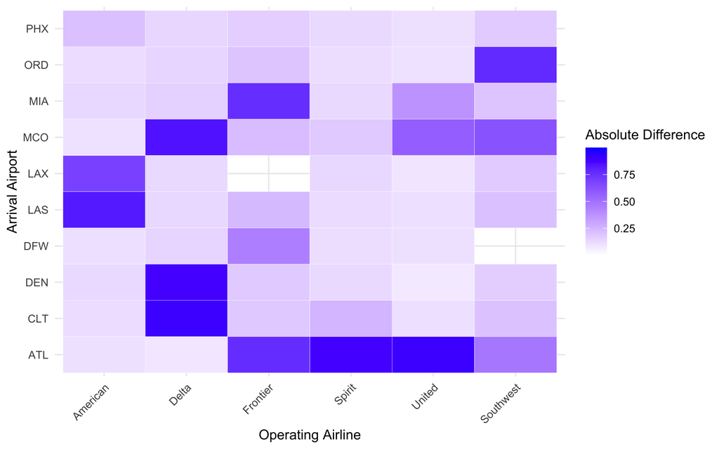

Heatmap of absolute difference of predicted vs. actual probability of flight delay.

```r
load(here("r_data",'finalGLM.RData'))
load(file = here("r_data","all_data_subsetted_with_joins_and_transformations_NAs_processed.RData"))
full <- full %>% filter(!(Operating_Airline %in% c("G4", "AS", "B6")))
#grab the predicted values
predicted_probs <- as.data.frame(predict(finalGLM, type = "response"))
colnames(predicted_probs) <- "predicted_prob"


cols_of_interest <- full %>% select(Dest, Operating_Airline, probCarrierDelay) %>% rename(actual_prob = probCarrierDelay) %>% bind_cols(predicted_probs) %>% mutate(actual_prob = as.numeric(as.character(actual_prob)), predicted_prob = as.numeric(predicted_prob)) %>% mutate(abs_dif = abs(actual_prob - predicted_prob))

# Create a heatmap ggplot2
heatmap_plot <- cols_of_interest %>%
  ggplot(aes(x = Operating_Airline, y = Dest)) +
  geom_tile(aes(fill = abs_dif), color = "white") +
  scale_fill_gradient(low = "white", high = "blue") +
  labs(x = "Operating Airline", y = "Arrival Airport") +
  theme_minimal() +
  theme(axis.text.x = element_text(angle = 45, hjust = 1)) +
  scale_x_discrete(labels = c("AA" = "American", "DL" = "Delta", "F9" = "Frontier", "NK" = "Spirit", "AS" = "Alaska", "UA" = "United", "WN" = "Southwest")) +
  labs(fill = "Absolute Difference")

# Save the heatmap plot
saveRDS(heatmap_plot, file = here("plots", "heatmap_plot.rds"))
```